# Coursework Report

*N* removed NAs: 3

*N* removed typo: 1

*N* removed <18: 16

*N* total clean: 130

| Group | *N* | *M*<sub>age</sub> | *M*<sub>rating</sub> |
| --- | --- | --- | --- |
| Control | 69 | 20.2 | 5.45 |
| Experim | 61 | 20.7 | 6.08 |

**Main analysis results**

*t*(128) = -4.36, *p* < .001

[interactive chart not shown]

[figure not shown]

[interactive chart not shown]

# Coursework Report

Analysing Data, Spring 2020

# Methods

## Participants

Table 1 *Descriptive Statistics by Condition and Age*

| Condition | *N* | Mean Age | Age SD | Min. Age | Max. Age |
| --- | --- | --- | --- | --- | --- |
| White | 69 | 20.2 | 1.81 | 18 | 24 |
| Red | 61 | 20.7 | 1.73 | 18 | 24 |

## Design

The research question being asked is whether the colour red influences male attractiveness to women. In order to investigate this question, attractiveness is first operationalised. This is done by measuring it on a rating scale of 1 to 9. 1 being not attractive at all and 9 being extremely attractive. The participants are asked three questions in response to a stimulus, “How attractive do you think this person is?”, “How pleasant is this person to look at?”, and “If I were to meet the person in this picture face to face, I would think he is attractive.” The response to these questions is a number on the scale. The rating given for each of the questions are combined to find the mean attractiveness score.

The participants were divided into two groups. Each group took part in one of two conditions. In one condition, the stimulus was a photo of a man in front of a white background, the control condition, and in the other condition a photo of a man in front of a red background was shown, the experimental condition.

Based on the results of the original study by Elliot et al., the operational hypothesis which we will be testing is women will rate men as more attractive on an attractiveness scale when they are in front of a red background than when they are in front of the white background. In order to test whether the difference between the conditions is significant, an unpaired *t*-test will be carried out.

# Results

The unpaired *t*-test was carried out because this is a between-groups design. This statistical test compared the means of the two conditions to determine if there is a significant difference between the two means. The statistical analysis indicated that men who were placed in front of a red background were rated as more attractive (*M* = 6.08) than men who were placed in front of a white background (*M* = 5.45). This difference in the means was significant (*M*<sub>diff</sub> = -0.626, 95% CI [-0.91, -0.34], *t*(128) = -4.36, *p* < .001)

As analysed in the *t*-test, the mean attractiveness in the red condition was 6.08 and in the white condition the mean was 5.45. This means the difference between the means was -0.63. The *t* value found was -4.36, this value is useful because we can use it to say that the difference between the means (-0.63) is 4.36 times greater than the standard error of the difference in means. In simple terms, that means that the difference between the means is great enough to be different from the standard error value.

The null hypothesis states that there would be no difference in attractiveness ratings between the two groups, meaning that the colour background does not influence male attractiveness to women. As *t* value is relatively high, and the probability is small (<.001), it is unlikely that the two means come from the same population, so they are more likely to be from different groups. This means that we can reject the null hypothesis. Therefore, the difference between the two colour conditions is significant when p < .001. We can now say with confidence say that the red background causes male attractiveness to be significantly higher than the white background.

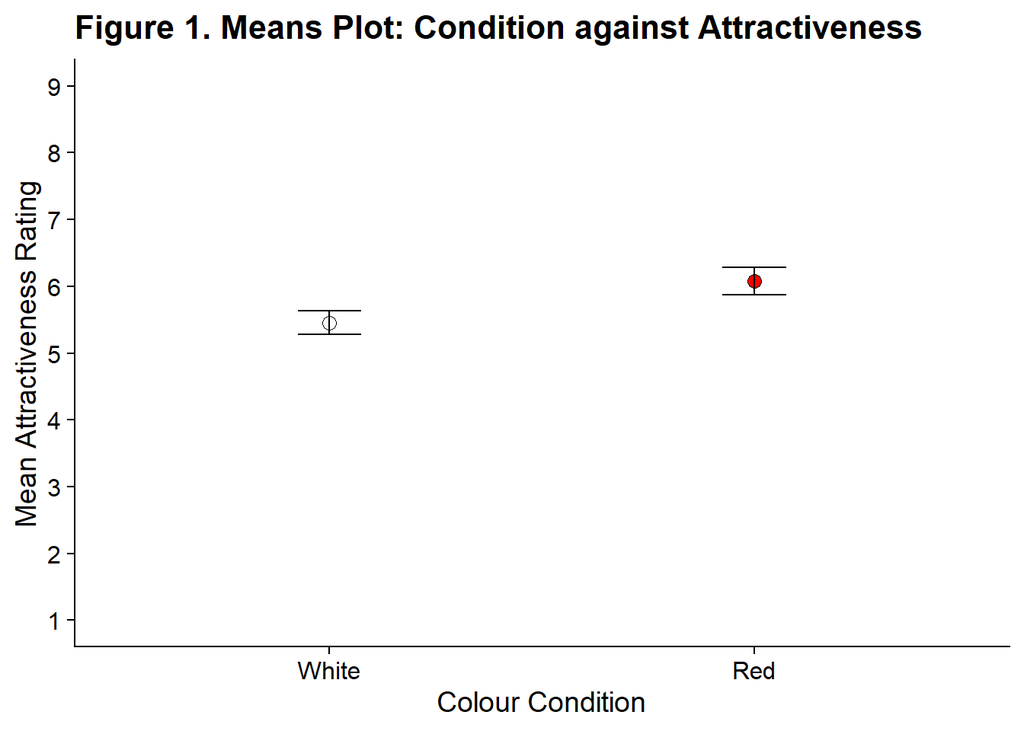

# Discussion

This research set out to investigate the importance of the colour red in determining the attractiveness of men to a sample of female participants. Descriptive and inferential statistics established useful information about the ratings of attractiveness of men shown in images, using three questions as a guide. The difference between the results of the two different conditions can be seen in the calculated means and standard deviations. It is clear from mean along with Figure 1., that the red colour condition produced a higher attractiveness rating than the white colour condition, with the red point on the graph being higher than the white point. The standard deviations of both conditions are also very similar, meaning the spread of data is similar. This set of results exhibits the difference between the two colour conditions and how red positively influences attraction of males to female participants.

The t test shows that this difference in the means is statistically significant under this probability (p < .001). The two points on the graph are unlikely to have been found from the same group of participants, meaning that the different colour backgrounds seen actually have an impact on the ratings of attractiveness rather than the differences in the ratings being by chance.

As this study establishes a statistically significant difference in mean attractiveness ratings, we can accept our original hypothesis. Men who are placed in front of a red background, are more likely to be rated as more attractive than men who were placed in front of a white background.

These results can be compared with that of the original study by Elliot et al. (2010). The original study agrees with our results, showing a significant colour effect. The man in front of the red background was rated as more attractive than the man in front of the white. This suggests that the method used in both studies is reliable because the same pattern of results is seen, even when different groups of participants are used. The impact of the consistency in the findings is that it allows us to form a strong argument stating that red increases attractiveness as this pattern of results appeared on more than one occasion. In addition, the similarity between the two studies has an impact on the relevance of our study in the wider field of research because our findings reinforce pre-existing ideas and provide further evidence to support the argument. There is also research available to support the idea that red increases attractiveness but using a different method. Berthold et al. (2017) found that participants were more likely to rate themselves as more attractive if they were wearing red than if they were wearing blue. This piece of evidence also supports our argument and provides more evidence so that we can say that red has an effect on attractiveness even when attractiveness is taken in a different context.

However, there is contradictory evidence to suggest that there is not a relationship between the two variables. Hesslinger et al. (2015) carried out another replication of Elliot’s study and found no significant difference between red and white conditions. This suggests replications of the same method do not all show the same consistency of results. Additionally, Peperkoorn et al. (2016) carried out a variation of this study and found that in short-term conditions, women were rated as more attractive in the white condition, with colour being the least influential factor on attractiveness. These two studies contradict our research along with the original investigation, stating that the colour red doesn’t always influence attraction, whether it being male or female attraction. This contradicting evidence has a negative impact on the relevance of our replication on the research question because it weakens the strength of the argument by saying that red doesn’t always influence attractiveness.

Aside from the supporting and conflicting evidence, there is issues within the method used to test the relationship that could question the integrity of the argument. An example of a limitation is that the features of the man himself could have influenced how attractive the woman finds him not the colour background he is standing in front of. This suggests a lack of validity because we could be studying how different features of a man impact his attractiveness rather than red influencing the attractiveness. This idea is shown to be an issue in research by Hesslinger et al. (2015). They produced another condition within the study and changed the clothes the man was wearing in the photo. They found that a man in formal clothes, whether they be in front of a white or red background, was found more attractive than one in casual clothes. This shows the effects of extraneous variables in the perceived attractiveness of the man, which could be seen in our findings. This would negatively impact the argument we are making and make it less reliable in the wider context.

Our study establishes a significant association between the colour red and attractiveness in males, with many other pieces of research supporting the results. Although there is conflicting evidence which suggests an alternative view on this research area, our results along with many others suggest a difference between red and white colour conditions, so, there must be even a slight association between colour and attractiveness. However, I believe in order to gather a concrete understanding of whether red influences attractiveness, this research area needs to be studied further. An example of a more in-depth research question could be why red influences attractiveness. Perhaps, looking into evolutionary advantages of the colour red by investigating animals picking mates based on colour or looking into admirable personality traits associated with the colour, i.e. asking people to pair traits with colour to see if traits attributing to attractive qualities are grouped with red tone colours. These factors could influence who someone finds attractive, so it would be interesting to develop these points further. Investigating why could further our understanding and even show more evidence to suggest whether there is or isn’t a relationship between the two variables.

In conclusion, it is evident that this is an interesting research area which will continue to grow, as no one clear answer is able to answer the research question. Taking each piece of evidence into account, it must be it is difficult to say whether red actually influences attractiveness ratings of the opposite gender as there any many pieces of evidence on both sides of the argument. However, in my opinion, the findings of our study provide enough evidence to suggest there is a relationship and red does in fact have a positive effect on the attractiveness of a man.

# References

Berthold, A., Reese, G., & Martin, J. (2017). The effect of red color on perceived self-attractiveness. *European Journal of Social Psychology, 47*(5), 645–652.

Elliot, A. J., Niesta Kayser, D., Greitemeyer, T., Lichtenfeld, S., Gramzow, R. H., Maier, M. A., & Liu, H. (2010). Red, rank, and romance in women viewing men. *Journal of Experimental Psychology: General, 139*(3), 399–417.

Hesslinger, V. M., Goldbach, L., & Carbon, C.-C. (2015). Men in red: A reexamination of the red-attractiveness effect. *Psychonomic Bulletin & Review, 22*(4), 1142–1148.

Peperkoorn, L. S., Roberts, S. C., & Pollet, T. V. (2016). Revisiting the Red Effect on Attractiveness and Sexual Receptivity: No Effect of the Color Red on Human Mate Preferences. *Evolutionary Psychology, 14*(4).